# Effect of an organic food intervention on biomarkers of exposure to lead and cadmium in primary school children: A cluster-randomized cross-over trial - Part 2

Nikolaos Efthymiou

18/08/2022

# Regression analysis (mixed effects models)

This script includes the regression analysis (Part 2). The output of the Part 1 script needs to be created (organiko_metals_part1.rds)

## Main analysis

### Primary outcomes

Selection of models for the analysis of main outcomes:

Mixed Effect Model:

- Outcome: Pb/Cd
- Variable of interest: organic treatment (vs conventional)
- Random part: participants
- Adjustment for: baseline levels of outcome (Pb/Cd), time (days from treatment), creatinine
- Creatinine adjustment:
  - Pb/Cd divided by creatinine
  - raw measurements of Pb/Cd and creatinine as fixed effect
- Interaction term: time*phase
  - if p-value>0.1 remove from the model

|  | adj Pb 1000 TR |  |  | Pb 1000 TR |  |  | adj Cd 1000 TR |  |  | Cd 1000 TR |  |  |
| --- | --- | --- | --- | --- | --- | --- | --- | --- | --- | --- | --- | --- |
| Predictors | Estimates | CI | p | Estimates | CI | p | Estimates | CI | p | Estimates | CI | p |
| (Intercept) | -0.146 | -0.406 – 0.115 | 0.272 | 0.010 | -0.255 – 0.275 | 0.941 | 0.137 | -0.131 – 0.406 | 0.315 | 0.326 | 0.137 – 0.516 | **0.001** |
| adj Pb1000 BL | 0.106 | 0.026 – 0.185 | **0.009** |  |  |  |  |  |  |  |  |  |
| DaysfromTreatment | 0.003 | -0.007 – 0.013 | 0.543 | -0.004 | -0.014 – 0.007 | 0.488 | -0.004 | -0.014 – 0.007 | 0.497 | -0.012 | -0.019 – -0.006 | **<0.001** |
| phase [Organic] | 0.442 | 0.112 – 0.772 | **0.009** | 0.305 | -0.036 – 0.646 | 0.079 | 0.203 | -0.141 – 0.548 | 0.247 | -0.064 | -0.212 – 0.084 | 0.398 |
| DaysfromTreatment * phase [Organic] | -0.021 | -0.034 – -0.008 | **0.001** | -0.012 | -0.026 – 0.001 | 0.065 | -0.013 | -0.026 – 0.000 | 0.053 |  |  |  |
| Pb1000 BL |  |  |  | -0.013 | -0.085 – 0.059 | 0.720 |  |  |  |  |  |  |
| creatinine |  |  |  | 0.056 | -0.017 – 0.129 | 0.133 |  |  |  | 0.098 | 0.025 – 0.171 | **0.008** |
| adj Cd1000 BL |  |  |  |  |  |  | 0.009 | -0.074 – 0.092 | 0.834 |  |  |  |
| Cd1000 BL |  |  |  |  |  |  |  |  |  | -0.030 | -0.106 – 0.047 | 0.447 |
| Random Effects |  |  |  |  |  |  |  |  |  |  |  |  |
| σ<sup>2</sup> | 0.85 |  |  | 0.92 |  |  | 0.94 |  |  | 0.93 |  |  |
| τ<sub>00</sub> | 0.06 <sub>ID</sub> |  |  | 0.01 <sub>ID</sub> |  |  | 0.04 <sub>ID</sub> |  |  | 0.02 <sub>ID</sub> |  |  |
| ICC | 0.07 |  |  | 0.01 |  |  | 0.04 |  |  | 0.02 |  |  |
| N | 146 <sub>ID</sub> |  |  | 146 <sub>ID</sub> |  |  | 146 <sub>ID</sub> |  |  | 146 <sub>ID</sub> |  |  |
| Observations | 679 |  |  | 679 |  |  | 679 |  |  | 679 |  |  |
| Marginal R<sup>2</sup> / Conditional R<sup>2</sup> | 0.038 / 0.103 |  |  | 0.024 / 0.033 |  |  | 0.025 / 0.060 |  |  | 0.031 / 0.054 |  |  |

| effect | Response | term | estimate | std.error | statistic | df | p.value | p.adjust |
| --- | --- | --- | --- | --- | --- | --- | --- | --- |
| fixed | Cd1000_TR | DaysfromTreatment | -0.0123487 | 0.0032953 | -3.7473754 | 576.7507 | 0.0001967 | 0.0033435 |
| fixed | adj_Pb1000_TR | DaysfromTreatment:phaseOrganic | -0.0208480 | 0.0065201 | -3.1974809 | 612.0111 | 0.0014578 | 0.0123916 |
| fixed | adj_Pb1000_TR | adj_Pb1000_BL | 0.1055653 | 0.0405371 | 2.6041612 | 142.4403 | 0.0101862 | 0.0346331 |
| fixed | adj_Pb1000_TR | phaseOrganic | 0.4417379 | 0.1680906 | 2.6279748 | 597.3027 | 0.0088103 | 0.0346331 |
| fixed | Cd1000_TR | creatinine | 0.0983283 | 0.0372109 | 2.6424618 | 577.2748 | 0.0084539 | 0.0346331 |
| fixed | adj_Cd1000_TR | DaysfromTreatment:phaseOrganic | -0.0131474 | 0.0067948 | -1.9349186 | 617.8607 | 0.0534564 | 0.1514597 |
| fixed | Pb1000_TR | DaysfromTreatment:phaseOrganic | -0.0124452 | 0.0067386 | -1.8468448 | 634.3659 | 0.0652352 | 0.1584283 |
| fixed | Pb1000_TR | phaseOrganic | 0.3051513 | 0.1736472 | 1.7573062 | 614.8928 | 0.0793632 | 0.1686469 |
| fixed | Pb1000_TR | creatinine | 0.0559851 | 0.0372554 | 1.5027355 | 572.2270 | 0.1334589 | 0.2520891 |
| fixed | adj_Cd1000_TR | phaseOrganic | 0.2033791 | 0.1753944 | 1.1595527 | 601.0765 | 0.2466914 | 0.4193753 |
| fixed | Pb1000_TR | DaysfromTreatment | -0.0036220 | 0.0052172 | -0.6942420 | 644.3833 | 0.4877806 | 0.6033534 |
| fixed | adj_Cd1000_TR | DaysfromTreatment | -0.0035894 | 0.0052801 | -0.6798025 | 629.9669 | 0.4968793 | 0.6033534 |
| fixed | Cd1000_TR | Cd1000_BL | -0.0295734 | 0.0388617 | -0.7609925 | 141.7263 | 0.4479259 | 0.6033534 |
| fixed | Cd1000_TR | phaseOrganic | -0.0637625 | 0.0754372 | -0.8452393 | 545.1525 | 0.3983480 | 0.6033534 |
| fixed | adj_Pb1000_TR | DaysfromTreatment | 0.0030838 | 0.0050709 | 0.6081250 | 622.9106 | 0.5433262 | 0.6157697 |
| fixed | Pb1000_TR | Pb1000_BL | -0.0131818 | 0.0367082 | -0.3590961 | 144.4646 | 0.7200475 | 0.7650505 |
| fixed | adj_Cd1000_TR | adj_Cd1000_BL | 0.0088749 | 0.0422639 | 0.2099882 | 143.7760 | 0.8339742 | 0.8339742 |

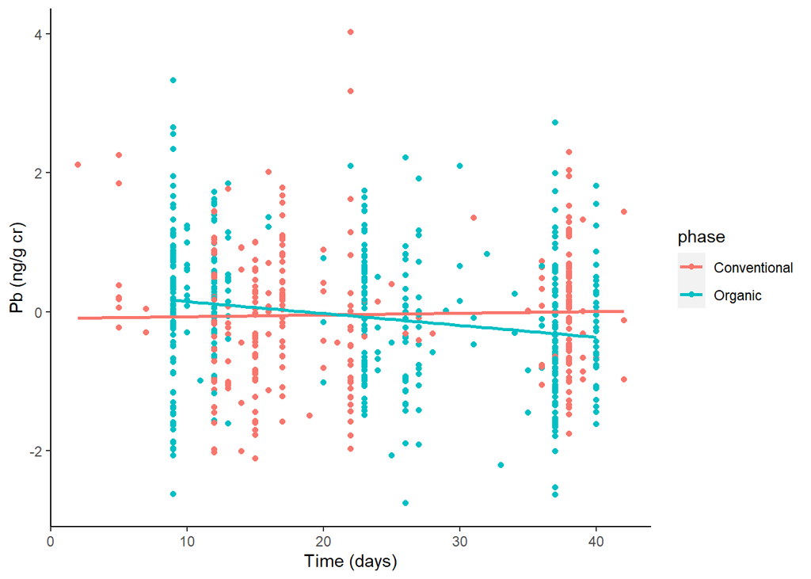

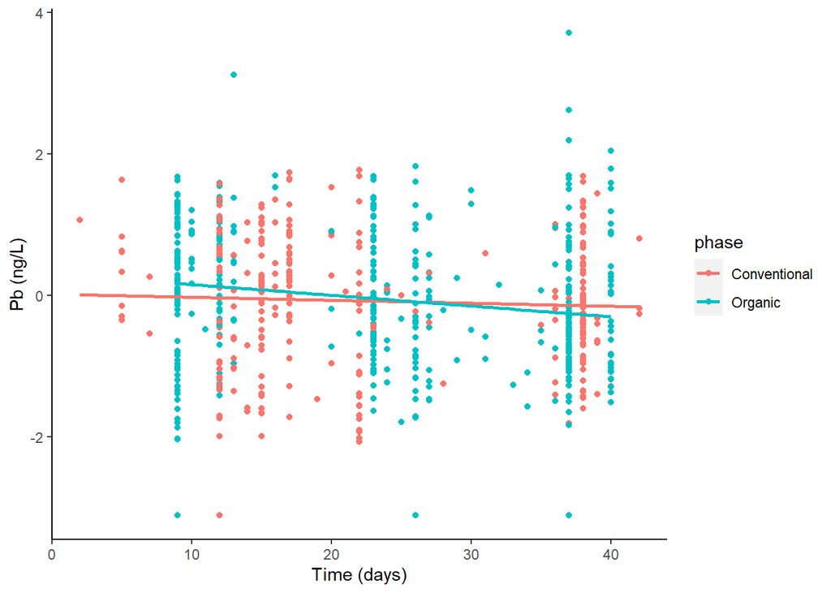

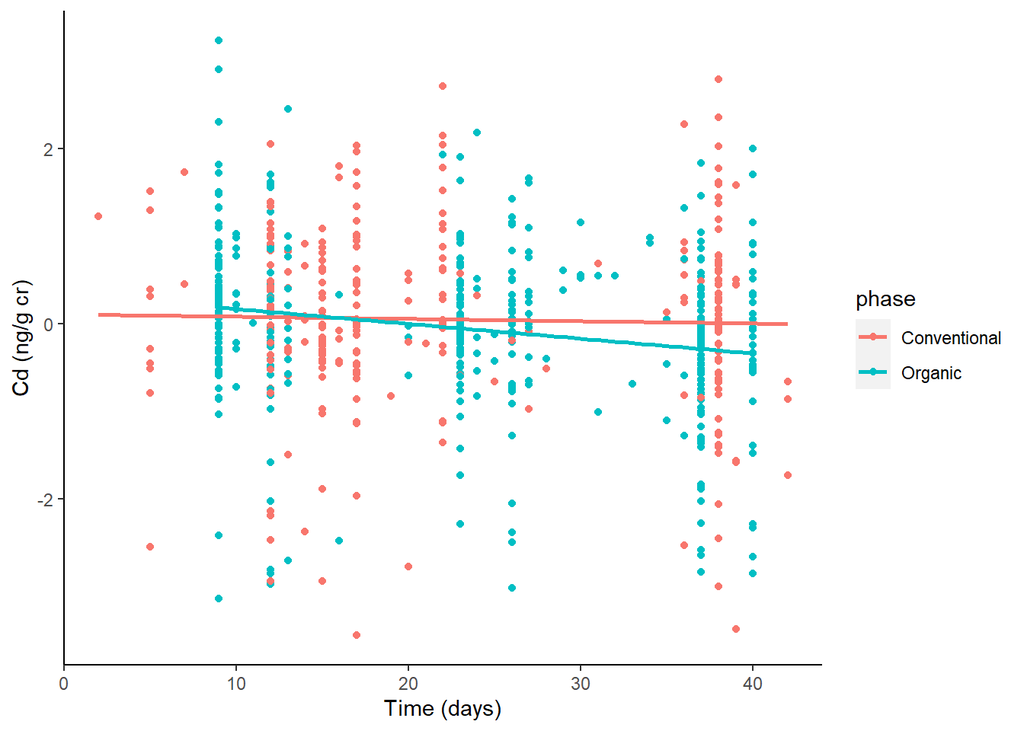

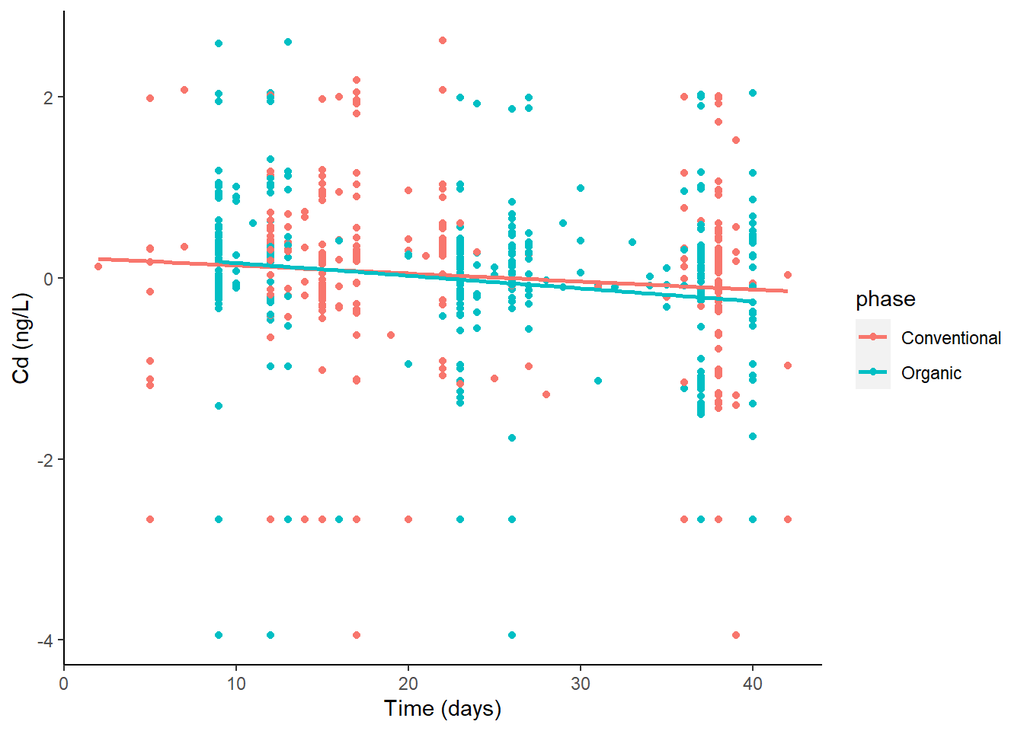

### Secondary outcomes

Selection of models for the analysis of secondary outcomes:

Mixed Effect Model:

- Outcome: 8-iso-PGF2a/MDA/8-OHdG
- Variable of interest: Cd/Pb
- Random part: participants
- Adjustment for: baseline levels of outcome (8-iso-PGF2a/MDA/8-OHdG), time (days from treatment), creatinine, age, sex
- Creatinine adjustment:
  - 8-iso-PGF2a/MDA/8-OHdG divided by creatinine
  - raw measurements of 8-iso-PGF2a/MDA/8-OHdG and creatinine as fixed effect

#### Creatinine adjusted 8-iso-PGF2a/MDA/8-OHdG

|  | adj Ohdg TR |  |  | adj Mda 1000 TR |  |  | adj Isopgf 2 a 1000 TR |  |  | adj Ohdg TR |  |  | adj Mda 1000 TR |  |  | adj Isopgf 2 a 1000 TR |  |  |
| --- | --- | --- | --- | --- | --- | --- | --- | --- | --- | --- | --- | --- | --- | --- | --- | --- | --- | --- |
| Predictors | Estimates | CI | p | Estimates | CI | p | Estimates | CI | p | Estimates | CI | p | Estimates | CI | p | Estimates | CI | p |
| (Intercept) | 0.045 | -0.175 – 0.264 | 0.690 | -0.207 | -0.404 – -0.010 | **0.040** | -0.136 | -0.329 – 0.057 | 0.167 | 0.041 | -0.166 – 0.248 | 0.697 | -0.194 | -0.387 – -0.000 | **0.050** | -0.089 | -0.277 – 0.100 | 0.354 |
| adj Ohdg BL | 0.189 | 0.079 – 0.300 | **0.001** |  |  |  |  |  |  | 0.152 | 0.046 – 0.259 | **0.005** |  |  |  |  |  |  |
| adj Cd1000 TR | 0.148 | 0.063 – 0.233 | **0.001** | 0.107 | 0.030 – 0.184 | **0.006** | 0.263 | 0.186 – 0.339 | **<0.001** |  |  |  |  |  |  |  |  |  |
| Sex [Female] | 0.042 | -0.160 – 0.245 | 0.681 | 0.041 | -0.140 – 0.222 | 0.658 | 0.117 | -0.061 – 0.294 | 0.198 | -0.010 | -0.204 – 0.185 | 0.922 | 0.013 | -0.165 – 0.191 | 0.887 | 0.073 | -0.100 – 0.247 | 0.408 |
| age baseline | -0.033 | -0.133 – 0.067 | 0.516 | -0.005 | -0.095 – 0.084 | 0.910 | 0.055 | -0.033 – 0.144 | 0.219 | -0.043 | -0.139 – 0.052 | 0.374 | -0.012 | -0.100 – 0.076 | 0.787 | 0.042 | -0.044 – 0.128 | 0.338 |
| DaysfromTreatment | -0.002 | -0.009 – 0.006 | 0.617 | 0.006 | -0.000 – 0.013 | 0.057 | 0.005 | -0.002 – 0.011 | 0.133 | 0.000 | -0.007 – 0.007 | 0.919 | 0.007 | 0.000 – 0.013 | **0.037** | 0.005 | -0.002 – 0.011 | 0.146 |
| adj Mda1000 BL |  |  |  | 0.140 | 0.040 – 0.240 | **0.006** |  |  |  |  |  |  | 0.141 | 0.042 – 0.239 | **0.005** |  |  |  |
| adj Isopgf2a1000 BL |  |  |  |  |  |  | 0.177 | 0.079 – 0.276 | **<0.001** |  |  |  |  |  |  | 0.173 | 0.077 – 0.270 | **<0.001** |
| adj Pb1000 TR |  |  |  |  |  |  |  |  |  | 0.388 | 0.303 – 0.472 | **<0.001** | 0.187 | 0.109 – 0.265 | **<0.001** | 0.320 | 0.244 – 0.397 | **<0.001** |
| Random Effects |  |  |  |  |  |  |  |  |  |  |  |  |  |  |  |  |  |  |
| σ<sup>2</sup> | 0.89 |  |  | 0.93 |  |  | 0.84 |  |  | 0.77 |  |  | 0.92 |  |  | 0.82 |  |  |
| τ<sub>00</sub> | 0.09 <sub>ID</sub> |  |  | 0.10 <sub>ID</sub> |  |  | 0.09 <sub>ID</sub> |  |  | 0.09 <sub>ID</sub> |  |  | 0.09 <sub>ID</sub> |  |  | 0.08 <sub>ID</sub> |  |  |
| ICC | 0.09 |  |  | 0.09 |  |  | 0.09 |  |  | 0.11 |  |  | 0.09 |  |  | 0.09 |  |  |
| N | 110 <sub>ID</sub> |  |  | 145 <sub>ID</sub> |  |  | 141 <sub>ID</sub> |  |  | 110 <sub>ID</sub> |  |  | 145 <sub>ID</sub> |  |  | 141 <sub>ID</sub> |  |  |
| Observations | 509 |  |  | 678 |  |  | 627 |  |  | 509 |  |  | 678 |  |  | 627 |  |  |
| Marginal R<sup>2</sup> / Conditional R<sup>2</sup> | 0.056 / 0.144 |  |  | 0.030 / 0.121 |  |  | 0.096 / 0.181 |  |  | 0.166 / 0.255 |  |  | 0.051 / 0.135 |  |  | 0.126 / 0.203 |  |  |

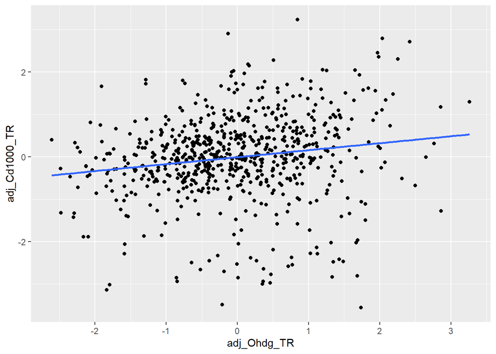

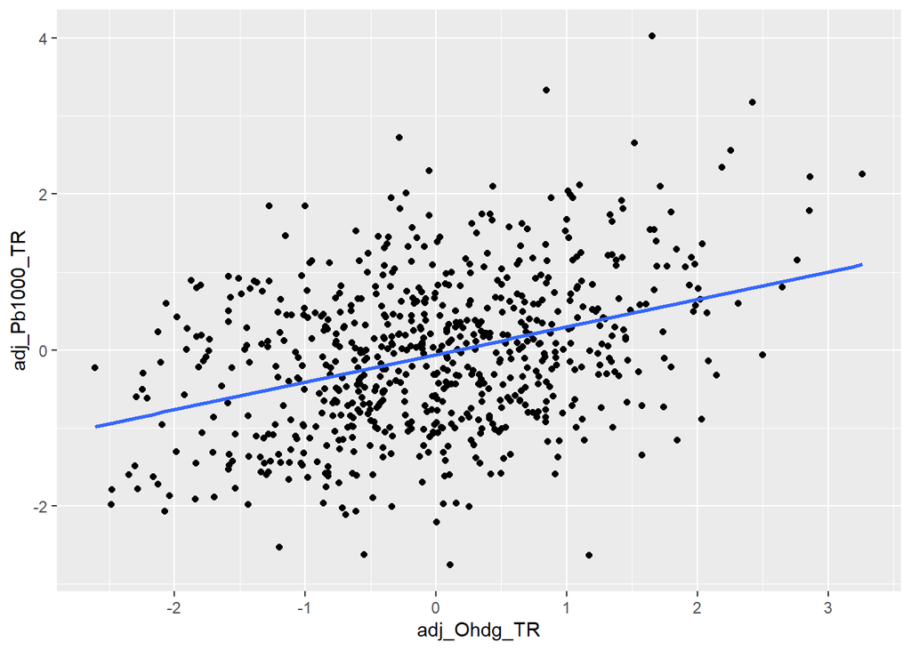

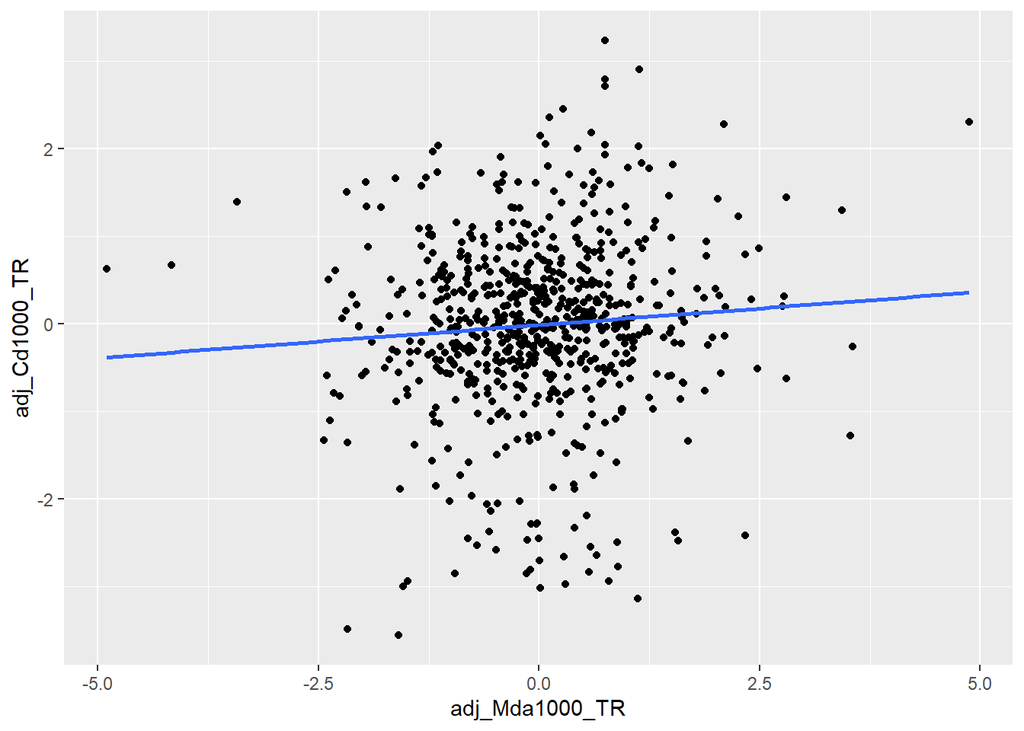

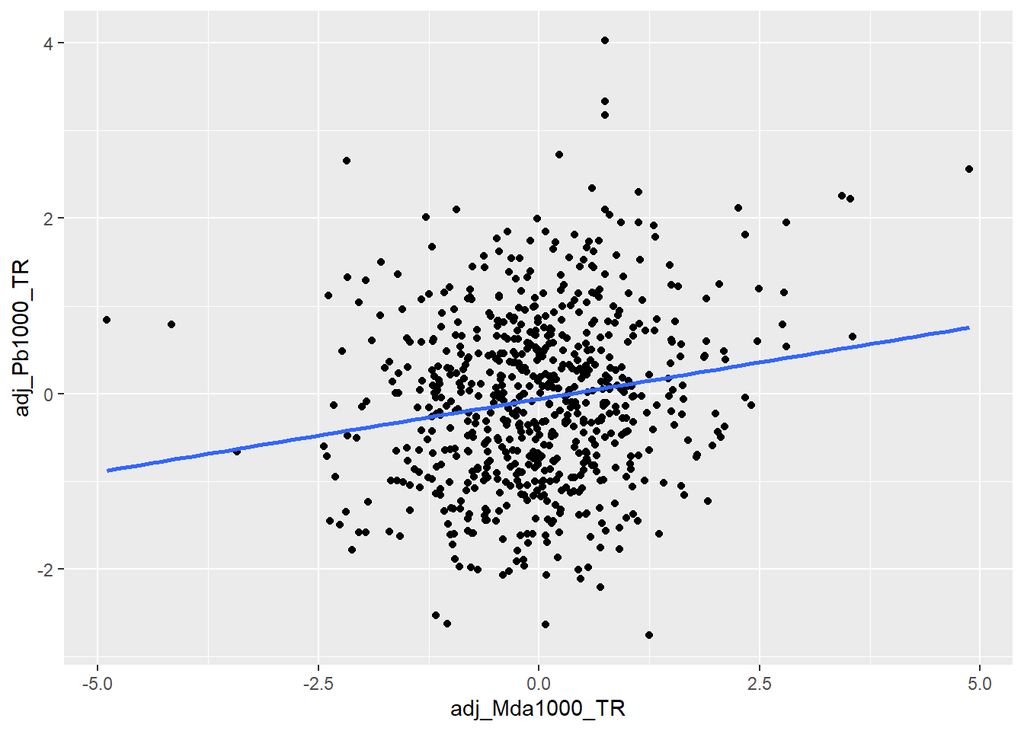

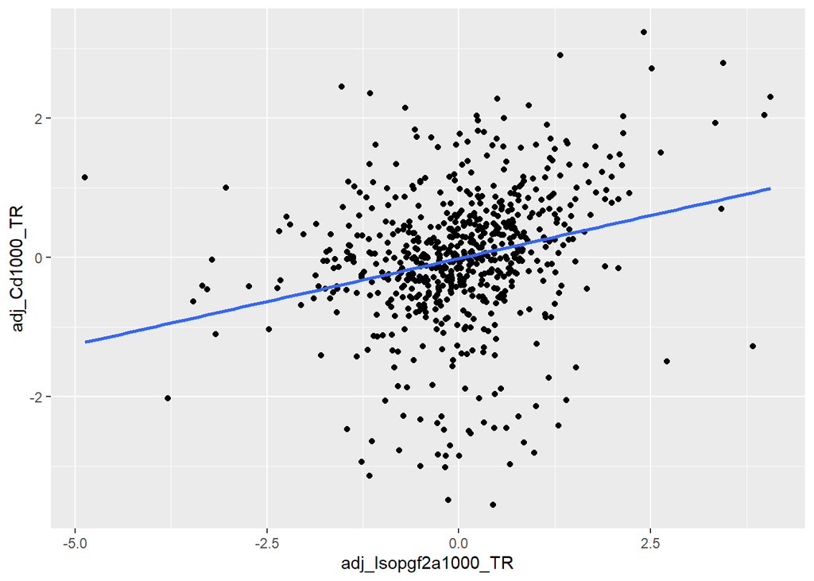

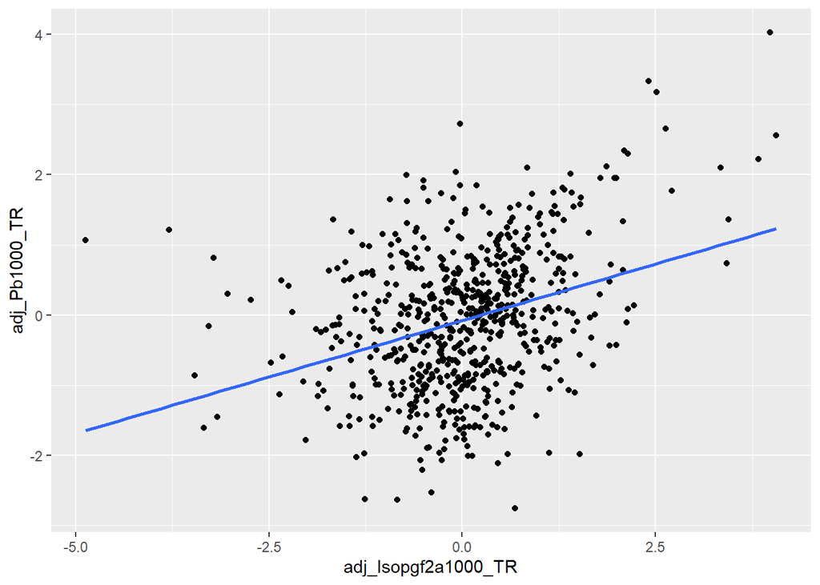

#### Raw measurements of 8-iso-PGF2a/MDA/8-OHdG and creatinine as fixed effect

|  | Ohdg TR |  |  | Mda 1000 TR |  |  | Isopgf 2 a 1000 TR |  |  | Ohdg TR |  |  | Mda 1000 TR |  |  | Isopgf 2 a 1000 TR |  |  |
| --- | --- | --- | --- | --- | --- | --- | --- | --- | --- | --- | --- | --- | --- | --- | --- | --- | --- | --- |
| Predictors | Estimates | CI | p | Estimates | CI | p | Estimates | CI | p | Estimates | CI | p | Estimates | CI | p | Estimates | CI | p |
| (Intercept) | 0.136 | -0.076 – 0.347 | 0.208 | -0.097 | -0.217 – 0.022 | 0.111 | -0.035 | -0.213 – 0.143 | 0.700 | 0.099 | -0.112 – 0.309 | 0.357 | -0.104 | -0.223 – 0.015 | 0.086 | -0.035 | -0.211 – 0.142 | 0.699 |
| Ohdg BL | 0.115 | 0.015 – 0.215 | **0.025** |  |  |  |  |  |  | 0.114 | 0.013 – 0.216 | **0.028** |  |  |  |  |  |  |
| creatinine | 0.318 | 0.233 – 0.403 | **<0.001** | 0.772 | 0.725 – 0.819 | **<0.001** | 0.397 | 0.326 – 0.469 | **<0.001** | 0.299 | 0.214 – 0.383 | **<0.001** | 0.770 | 0.723 – 0.817 | **<0.001** | 0.397 | 0.326 – 0.468 | **<0.001** |
| Cd1000 TR | -0.070 | -0.152 – 0.011 | 0.088 | -0.013 | -0.060 – 0.034 | 0.582 | 0.009 | -0.062 – 0.080 | 0.803 |  |  |  |  |  |  |  |  |  |
| Sex [Female] | -0.021 | -0.217 – 0.174 | 0.830 | 0.033 | -0.078 – 0.144 | 0.555 | 0.090 | -0.074 – 0.253 | 0.283 | -0.033 | -0.231 – 0.166 | 0.746 | 0.033 | -0.078 – 0.144 | 0.559 | 0.087 | -0.076 – 0.251 | 0.295 |
| age baseline | -0.050 | -0.146 – 0.047 | 0.310 | -0.008 | -0.064 – 0.047 | 0.771 | 0.038 | -0.043 – 0.120 | 0.359 | -0.051 | -0.149 – 0.047 | 0.308 | -0.008 | -0.064 – 0.047 | 0.765 | 0.037 | -0.044 – 0.119 | 0.368 |
| DaysfromTreatment | -0.004 | -0.011 – 0.003 | 0.250 | 0.003 | -0.001 – 0.007 | 0.113 | 0.002 | -0.004 – 0.008 | 0.557 | -0.002 | -0.009 – 0.005 | 0.567 | 0.004 | -0.000 – 0.007 | 0.077 | 0.002 | -0.004 – 0.008 | 0.534 |
| Mda1000 BL |  |  |  | 0.110 | 0.045 – 0.175 | **0.001** |  |  |  |  |  |  | 0.110 | 0.045 – 0.175 | **0.001** |  |  |  |
| Isopgf2a1000 BL |  |  |  |  |  |  | 0.119 | 0.040 – 0.197 | **0.003** |  |  |  |  |  |  | 0.119 | 0.040 – 0.197 | **0.003** |
| Pb1000 TR |  |  |  |  |  |  |  |  |  | 0.133 | 0.051 – 0.216 | **0.002** | 0.018 | -0.029 – 0.065 | 0.460 | 0.020 | -0.050 – 0.090 | 0.572 |
| Random Effects |  |  |  |  |  |  |  |  |  |  |  |  |  |  |  |  |  |  |
| σ<sup>2</sup> | 0.81 |  |  | 0.33 |  |  | 0.70 |  |  | 0.79 |  |  | 0.33 |  |  | 0.70 |  |  |
| τ<sub>00</sub> | 0.09 <sub>ID</sub> |  |  | 0.04 <sub>ID</sub> |  |  | 0.08 <sub>ID</sub> |  |  | 0.10 <sub>ID</sub> |  |  | 0.04 <sub>ID</sub> |  |  | 0.08 <sub>ID</sub> |  |  |
| ICC | 0.10 |  |  | 0.11 |  |  | 0.11 |  |  | 0.11 |  |  | 0.12 |  |  | 0.11 |  |  |
| N | 110 <sub>ID</sub> |  |  | 145 <sub>ID</sub> |  |  | 141 <sub>ID</sub> |  |  | 110 <sub>ID</sub> |  |  | 145 <sub>ID</sub> |  |  | 141 <sub>ID</sub> |  |  |
| Observations | 509 |  |  | 678 |  |  | 627 |  |  | 509 |  |  | 678 |  |  | 627 |  |  |
| Marginal R<sup>2</sup> / Conditional R<sup>2</sup> | 0.119 / 0.207 |  |  | 0.635 / 0.677 |  |  | 0.193 / 0.278 |  |  | 0.130 / 0.230 |  |  | 0.635 / 0.677 |  |  | 0.193 / 0.279 |  |  |

| effect | Response | term | estimate | std.error | statistic | df | p.value | p.adjust |
| --- | --- | --- | --- | --- | --- | --- | --- | --- |
| fixed | Mda1000_TR | creatinine | 0.7722336 | 0.0239368 | 32.2613427 | 656.8928 | 0.0000000 | 0.0000000 |
| fixed | Mda1000_TR | creatinine | 0.7701452 | 0.0238797 | 32.2510975 | 654.9943 | 0.0000000 | 0.0000000 |
| fixed | Isopgf2a1000_TR | creatinine | 0.3973117 | 0.0362719 | 10.9537146 | 592.7238 | 0.0000000 | 0.0000000 |
| fixed | Isopgf2a1000_TR | creatinine | 0.3967900 | 0.0362333 | 10.9509725 | 590.1026 | 0.0000000 | 0.0000000 |
| fixed | adj_Ohdg_TR | adj_Pb1000_TR | 0.3877458 | 0.0429098 | 9.0362943 | 500.8871 | 0.0000000 | 0.0000000 |
| fixed | adj_Isopgf2a1000_TR | adj_Pb1000_TR | 0.3202933 | 0.0390289 | 8.2065694 | 620.7990 | 0.0000000 | 0.0000000 |
| fixed | Ohdg_TR | creatinine | 0.3180778 | 0.0434022 | 7.3286015 | 474.0342 | 0.0000000 | 0.0000000 |
| fixed | Ohdg_TR | creatinine | 0.2985550 | 0.0430522 | 6.9347175 | 478.7897 | 0.0000000 | 0.0000000 |
| fixed | adj_Isopgf2a1000_TR | adj_Cd1000_TR | 0.2625185 | 0.0389765 | 6.7353042 | 613.1620 | 0.0000000 | 0.0000000 |
| fixed | adj_Mda1000_TR | adj_Pb1000_TR | 0.1871621 | 0.0398765 | 4.6935488 | 671.6816 | 0.0000033 | 0.0000215 |
| fixed | adj_Isopgf2a1000_TR | adj_Isopgf2a1000_BL | 0.1773621 | 0.0501986 | 3.5332064 | 130.6792 | 0.0005681 | 0.0031248 |
| fixed | adj_Isopgf2a1000_TR | adj_Isopgf2a1000_BL | 0.1732823 | 0.0490038 | 3.5360990 | 132.3162 | 0.0005604 | 0.0031248 |
| fixed | adj_Ohdg_TR | adj_Cd1000_TR | 0.1481265 | 0.0434143 | 3.4119314 | 502.4690 | 0.0006971 | 0.0035390 |
| fixed | adj_Ohdg_TR | adj_Ohdg_BL | 0.1892806 | 0.0562903 | 3.3625816 | 103.5936 | 0.0010829 | 0.0044888 |
| fixed | Mda1000_TR | Mda1000_BL | 0.1103286 | 0.0330856 | 3.3346445 | 145.1388 | 0.0010843 | 0.0044888 |
| fixed | Mda1000_TR | Mda1000_BL | 0.1103661 | 0.0331091 | 3.3334072 | 145.4635 | 0.0010882 | 0.0044888 |
| fixed | Ohdg_TR | Pb1000_TR | 0.1334619 | 0.0421275 | 3.1680440 | 490.0534 | 0.0016305 | 0.0063302 |
| fixed | Isopgf2a1000_TR | Isopgf2a1000_BL | 0.1189551 | 0.0399644 | 2.9765272 | 134.6239 | 0.0034576 | 0.0120407 |
| fixed | Isopgf2a1000_TR | Isopgf2a1000_BL | 0.1189160 | 0.0399622 | 2.9757159 | 134.6103 | 0.0034663 | 0.0120407 |
| fixed | adj_Ohdg_TR | adj_Ohdg_BL | 0.1522807 | 0.0541353 | 2.8129647 | 103.3013 | 0.0058766 | 0.0184692 |
| fixed | adj_Mda1000_TR | adj_Mda1000_BL | 0.1405864 | 0.0501635 | 2.8025623 | 140.5994 | 0.0057859 | 0.0184692 |
| fixed | adj_Mda1000_TR | adj_Cd1000_TR | 0.1071308 | 0.0391527 | 2.7362281 | 667.2024 | 0.0063801 | 0.0191404 |
| fixed | adj_Mda1000_TR | adj_Mda1000_BL | 0.1399819 | 0.0510507 | 2.7420146 | 140.2819 | 0.0069026 | 0.0198075 |
| fixed | Ohdg_TR | Ohdg_BL | 0.1151078 | 0.0510510 | 2.2547625 | 102.2787 | 0.0262794 | 0.0722684 |
| fixed | Ohdg_TR | Ohdg_BL | 0.1143421 | 0.0518126 | 2.2068395 | 101.5213 | 0.0295780 | 0.0780859 |
| fixed | adj_Mda1000_TR | DaysfromTreatment | 0.0069229 | 0.0033137 | 2.0891878 | 574.5224 | 0.0371302 | 0.0942536 |
| fixed | adj_Mda1000_TR | DaysfromTreatment | 0.0064028 | 0.0033526 | 1.9097884 | 572.8475 | 0.0566596 | 0.1385013 |
| fixed | Mda1000_TR | DaysfromTreatment | 0.0035429 | 0.0019972 | 1.7739289 | 569.8078 | 0.0766089 | 0.1805781 |
| fixed | Ohdg_TR | Cd1000_TR | -0.0704545 | 0.0412551 | -1.7077787 | 497.9613 | 0.0883007 | 0.2009602 |
| fixed | Mda1000_TR | DaysfromTreatment | 0.0031794 | 0.0020019 | 1.5882031 | 568.7983 | 0.1127961 | 0.2481514 |
| fixed | adj_Isopgf2a1000_TR | DaysfromTreatment | 0.0049775 | 0.0033076 | 1.5048941 | 511.3160 | 0.1329688 | 0.2830948 |
| fixed | adj_Isopgf2a1000_TR | DaysfromTreatment | 0.0047283 | 0.0032483 | 1.4556119 | 512.3272 | 0.1461124 | 0.3013569 |
| fixed | adj_Isopgf2a1000_TR | SexFemale | 0.1166721 | 0.0904613 | 1.2897463 | 131.6814 | 0.1993993 | 0.3987987 |
| fixed | adj_Isopgf2a1000_TR | age_baseline | 0.0553204 | 0.0449415 | 1.2309429 | 133.5889 | 0.2205070 | 0.4280431 |
| fixed | Ohdg_TR | DaysfromTreatment | -0.0042012 | 0.0036483 | -1.1515449 | 430.3971 | 0.2501474 | 0.4717066 |
| fixed | Isopgf2a1000_TR | SexFemale | 0.0895599 | 0.0832715 | 1.0755167 | 136.2736 | 0.2840439 | 0.5207472 |
| fixed | Ohdg_TR | age_baseline | -0.0499522 | 0.0491346 | -1.0166394 | 105.0838 | 0.3116600 | 0.5274246 |
| fixed | Ohdg_TR | age_baseline | -0.0509470 | 0.0499146 | -1.0206823 | 104.7158 | 0.3097573 | 0.5274246 |
| fixed | Isopgf2a1000_TR | SexFemale | 0.0873313 | 0.0833165 | 1.0481875 | 136.4459 | 0.2964054 | 0.5274246 |
| fixed | adj_Isopgf2a1000_TR | age_baseline | 0.0420690 | 0.0438711 | 0.9589231 | 135.3704 | 0.3393070 | 0.5598566 |
| fixed | adj_Ohdg_TR | age_baseline | -0.0434146 | 0.0487486 | -0.8905812 | 103.5862 | 0.3752177 | 0.5759156 |
| fixed | Isopgf2a1000_TR | age_baseline | 0.0382231 | 0.0416009 | 0.9188034 | 136.5370 | 0.3598187 | 0.5759156 |
| fixed | Isopgf2a1000_TR | age_baseline | 0.0374993 | 0.0416128 | 0.9011497 | 136.6774 | 0.3690939 | 0.5759156 |
| fixed | adj_Isopgf2a1000_TR | SexFemale | 0.0733070 | 0.0884862 | 0.8284572 | 133.9201 | 0.4088856 | 0.6133285 |
| fixed | Mda1000_TR | Pb1000_TR | 0.0176992 | 0.0239390 | 0.7393470 | 655.5188 | 0.4599610 | 0.6746095 |
| fixed | adj_Ohdg_TR | age_baseline | -0.0330734 | 0.0508626 | -0.6502492 | 104.9780 | 0.5169518 | 0.7243714 |
| fixed | Mda1000_TR | Cd1000_TR | -0.0130997 | 0.0237664 | -0.5511867 | 660.0638 | 0.5816922 | 0.7243714 |
| fixed | Mda1000_TR | SexFemale | 0.0333888 | 0.0565095 | 0.5908531 | 139.9259 | 0.5555720 | 0.7243714 |
| fixed | Isopgf2a1000_TR | DaysfromTreatment | 0.0017737 | 0.0030191 | 0.5874828 | 514.8823 | 0.5571371 | 0.7243714 |
| fixed | Ohdg_TR | DaysfromTreatment | -0.0020714 | 0.0036143 | -0.5731047 | 428.6807 | 0.5668743 | 0.7243714 |
| fixed | Mda1000_TR | SexFemale | 0.0330410 | 0.0565534 | 0.5842448 | 140.2534 | 0.5599941 | 0.7243714 |
| fixed | Isopgf2a1000_TR | Pb1000_TR | 0.0201450 | 0.0356229 | 0.5655050 | 612.2336 | 0.5719375 | 0.7243714 |
| fixed | Isopgf2a1000_TR | DaysfromTreatment | 0.0018716 | 0.0030055 | 0.6227172 | 513.3957 | 0.5337469 | 0.7243714 |
| fixed | adj_Ohdg_TR | DaysfromTreatment | -0.0019122 | 0.0038165 | -0.5010310 | 431.4119 | 0.6166049 | 0.7536282 |
| fixed | adj_Mda1000_TR | SexFemale | 0.0408616 | 0.0921321 | 0.4435108 | 141.0086 | 0.6580761 | 0.7896913 |
| fixed | adj_Ohdg_TR | SexFemale | 0.0423440 | 0.1030475 | 0.4109172 | 104.1780 | 0.6819773 | 0.8037589 |
| fixed | Mda1000_TR | age_baseline | -0.0082408 | 0.0282416 | -0.2917972 | 140.2287 | 0.7708729 | 0.8623324 |
| fixed | Ohdg_TR | SexFemale | -0.0327399 | 0.1011341 | -0.3237274 | 105.6434 | 0.7467844 | 0.8623324 |
| fixed | Mda1000_TR | age_baseline | -0.0084705 | 0.0282671 | -0.2996609 | 140.6858 | 0.7648781 | 0.8623324 |
| fixed | adj_Mda1000_TR | age_baseline | -0.0120831 | 0.0447301 | -0.2701329 | 143.3403 | 0.7874466 | 0.8661912 |
| fixed | Isopgf2a1000_TR | Cd1000_TR | 0.0090837 | 0.0363414 | 0.2499560 | 605.9406 | 0.8027061 | 0.8685017 |
| fixed | Ohdg_TR | SexFemale | -0.0214301 | 0.0994949 | -0.2153893 | 105.7628 | 0.8298786 | 0.8834191 |
| fixed | adj_Mda1000_TR | age_baseline | -0.0051689 | 0.0455319 | -0.1135235 | 143.0364 | 0.9097747 | 0.9221629 |
| fixed | adj_Ohdg_TR | SexFemale | -0.0096950 | 0.0989808 | -0.0979482 | 103.4619 | 0.9221629 | 0.9221629 |
| fixed | adj_Ohdg_TR | DaysfromTreatment | 0.0003651 | 0.0035687 | 0.1023121 | 429.0743 | 0.9185568 | 0.9221629 |
| fixed | adj_Mda1000_TR | SexFemale | 0.0129364 | 0.0907385 | 0.1425678 | 142.1850 | 0.8868334 | 0.9221629 |

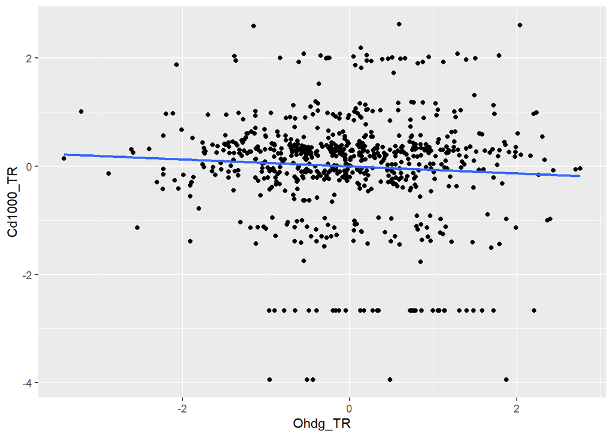

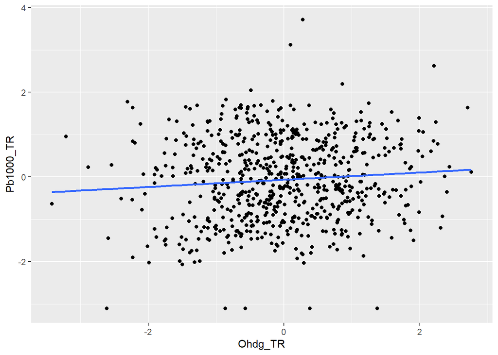

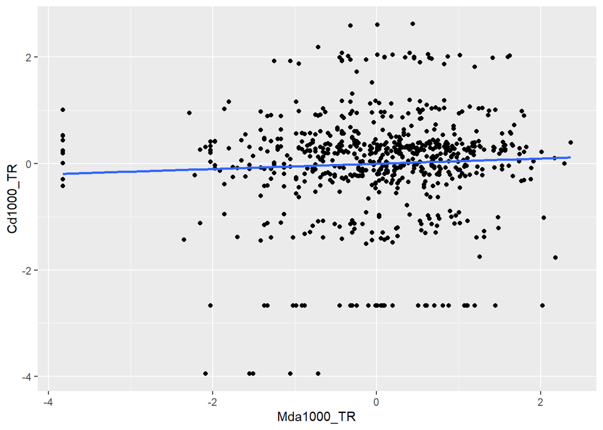

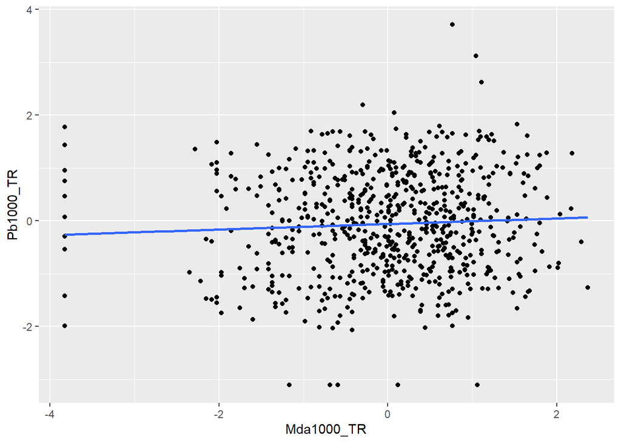

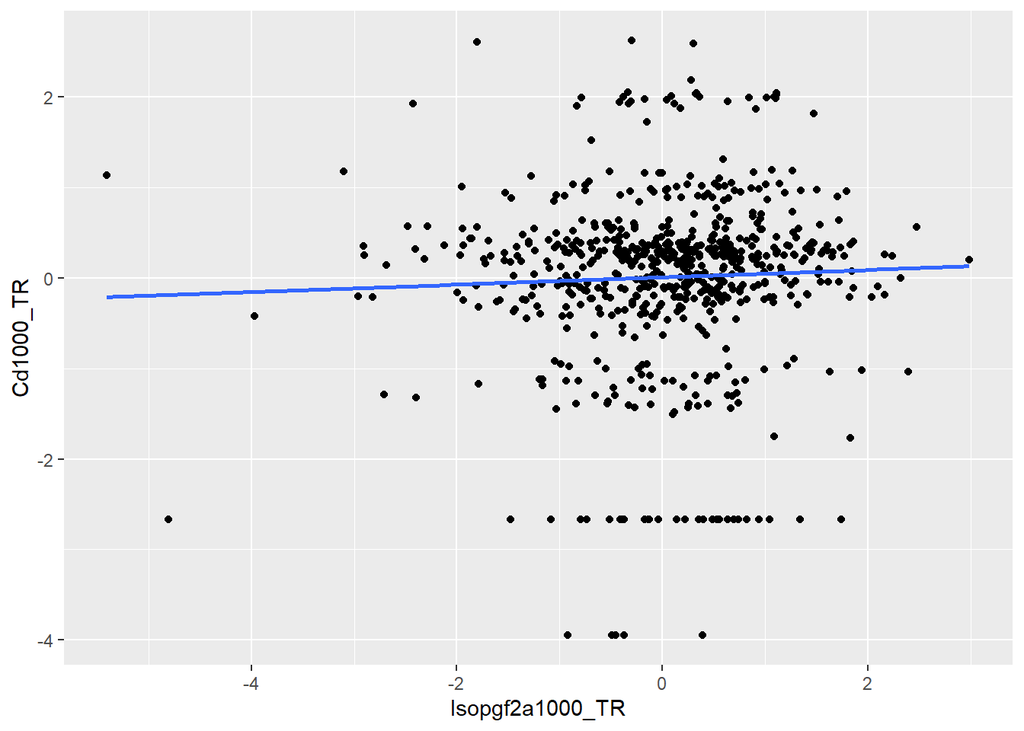

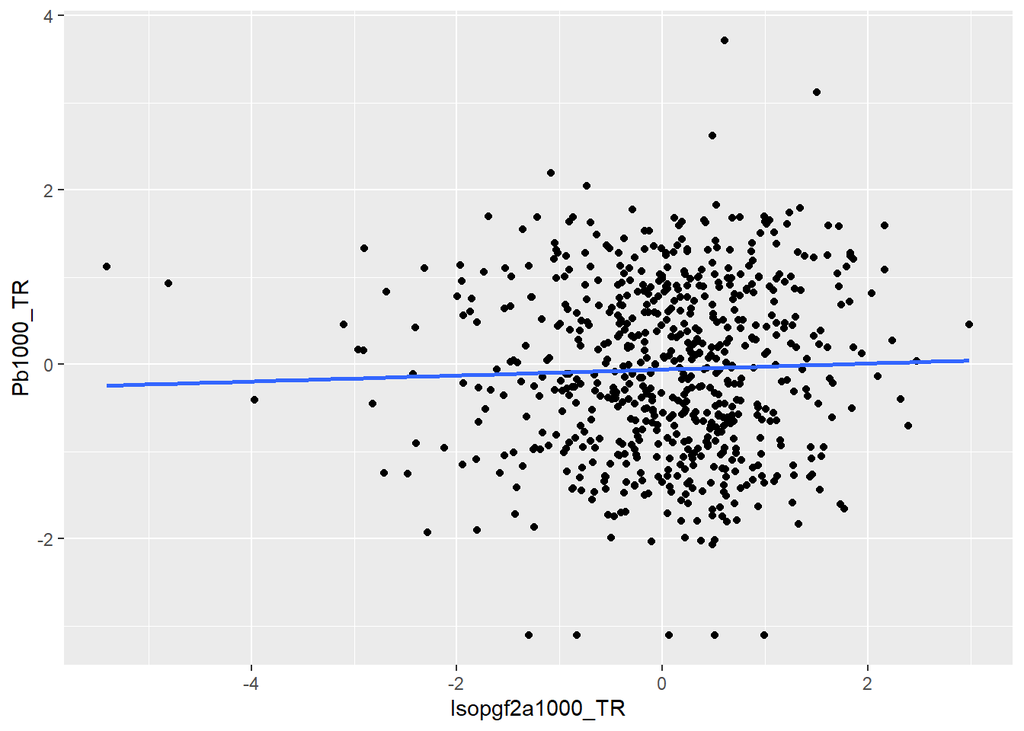